## ProgramaciÃ³n BÃ¡sica en R

- En comparaciÃ³n con otros paquetes como Stata, R tiene un costo de entrada relativamente mayor.
- Sin embargo, este costo se cubre rÃ¡pidamente debido a la versatilidad del programa para diversos procesos.
- ProgramaciÃ³n es un campo en el que R se desempeÃ±a relativamente bien. Sin embargo al hablar de programaciÃ³n se abre un universo de trabajo.

-Introduciremos algunos aspectos bÃ¡sicos de programaciÃ³n en R

- Lectores interesados en aprender a programar (en forma) pueden remitirse al libro de Matloff (2011), “The Art of R Programming”.

### Condicionales

- Los condicionales son expresiones que realizan alguna tarea de computaciÃ³n dependiendo en si la condiciÃ³n establecida es verdadera (TRUE) o falsa (FALSE)
- SÃ?mbolos condicionales

`<` `>` `==` `>=` `<=`

- El condicional principal es el `if()`, el cual realiza un tarea basada en una condiciÃ³n simple.
- La estructura para un condicional `if()` es la siguiente:

`if(condition){`

`expresion verdadera`

`} else{`

`expresion falsa`

`}`

- Noten que un condicionales tiene tres componentes: el condicional, una expresiÃ³n verdadera y una falsa.
- Si la condiciÃ³n se cumple, desarrollarÃ¡ el cÃ³digo en la expresiÃ³n verdadera, de lo contrario, desarrollarÃ¡ el cÃ³digo de la expresiÃ³n falsa.
- Veamos un ejemplo:

```r
x <- 0.9

if(x > 0.5){
  print(x)
  print("Es cara")
} else {
  print(x)
  print("Es sello")
}
```

```
## [1] 0.9
## [1] "Es cara"
```

- Noten ahora el resultado cuando no se cumple la condiciÃ³n.

```r
x <- 0.49

if(x > 0.5){
  print(x)
  print("Es cara")
} else {
  print(x)
  print("Es sello")
}
```

```
## [1] 0.49
## [1] "Es sello"
```

- R por defecto solo necesita la condiciÃ³n verdadera para funcionar, de manera que no siempre es necesario establecer una condiciÃ³n falsa.

```r
x <- 0.49

if(x > 0.5){
  print(x)
  print("Es cara")
} else {}
```

- Se puede considerar mÃ¡s de dos opciones verdaderas incluyendo `else if()` el la estructura del condicional.

```r
x <- runif(1) #runif(n) me genera un vector de tamaÃÂ±o n de nÃÂºmeros aleatorios entre 0 y 1

if(x > 0.5){
  print(x)
  x <- x + 0.1 #x se estÃÂ¡ sobre escribiendo para tomar un valor nuevo
  print(x)
} else if(x == 0.5) {
  print(x)
  x <- x + 0.2
  print(x)
} else{
  x
}
```

```
## [1] 0.04350397
```

- En el cÃ³digo anterior estamos adicionando una condiciÃ³n, y esto puede repetirse con n condiciones mÃ¡s incluyendo `else if()`.
- R entenderÃ¡ que el condicional terminÃ³ con `else`
- Nota: Estamos aprendiendo algo adicional, puedo sobre escribir variables.
- En `x <- x + 1` estamos usando la x inicial para crear un nuevo valor de x.

```r
x <- 5
x
```

```
## [1] 5
```

```r
x <- x + 5
x
```

```
## [1] 10
```

- Tengan esto en cuenta para mÃ¡s adelante.
- El condicional `if()` se puede aplicar para cualquier expresiÃ³n lÃ³gica, sin importar el tipo de dato.
- En el ejemplo anterior usamos nÃºmeros, usemos ahora otro tipo de dato.

```r
texto <- "Big Data"

if(is.character(texto) == TRUE ){
  print(texto)
} else{
  print("Mi variable no es de tipo texto")
}
```

```
## [1] "Big Data"
```

```r
texto <- FALSE

if(is.character(texto) == TRUE ){ #is.character(var) es una funciÃÂ³n que me regresa TRUE si var es tipo character y FALSE en caso contrario
  print(texto)
} else{
  print("Mi variable no es de tipo texto")
}
```

```
## [1] "Mi variable no es de tipo texto"
```

- Noten que las opciones para establecer un condicional son (casi) infinitas. A medida que avancemos esto tomarÃ¡ mÃ¡s sentido.
- Noten tambiÃ©n que en los ejemplos anteriores usamos varias funciones como `runif()` o `is.character()` para definir los condicionales.
- Es muy probable que al imaginarse una condiciÃ³n exista una funciÃ³n que les ayude, es responsabilidad de ustedes buscar la funciÃ³n que necesiten en cada caso.

### Iteraciones y loops

- Un loop es una forma de repetir un secuencia de instrucciones bajo ciertas condiciones.
- Permite automatizar partes de un cÃ³digo que necesitan repeticiÃ³n.
- Existen mÃºltiples funciones para desarrollar un loop, pero las mÃ¡s comunes (y prÃ¡cticas) son `for()` y `while()`.
- Empecemos por la funciÃ³n `for()`. La sintaxis es la siguiente:

`for(expresion){`

`tarea a desarrollar`

`}`

```r
x <- c(5, 12, 13)

for (n in x)

  print(n^2)
```

```
## [1] 25
## [1] 144
## [1] 169
```

- AcÃ¡ le pedimos que a cada elemento del vector le saque el cuadrado. Noten que n toma cada valor del vector.
- Noten que el `for()` se puede leer como: para cada objeto n del vector x realiza la tarea definida.
- Noten ademÃ¡s que estamos yendo objeto por objeto. Podemos hacerlo con la posiciÃ³n:

```r
x <- c(5, 12, 13)

for (i in 1:length(x)){ #lenght(x) me genera un nÃÂºmero que es igual al largo del vector x
  print(x[i]^2)
}
```

```
## [1] 25
## [1] 144
## [1] 169
```

- En el cÃ³digo anterior, en vez de cada n del vector x, tendremos que la funciÃ³n de generarÃ¡ para cada posiciÃ³n i del vector x.
- AdemÃ¡s, podemos combinar un loop con un condicional:

```r
nombre_sujeto <- c("James", "Radamel", "David")
numero_goles <- c(109, 249, 0)
juega_francia <- c(FALSE, TRUE, FALSE)
posicion <- factor(c("volante", "delantero", "arquero"))
gravedad_lesion <- factor(c("severa", "moderada", "leve"), levels = c("leve", "moderada", "severa"), ordered=TRUE)

jugadores_seleccion <- data.frame(nombre_sujeto, numero_goles, posicion, juega_francia, gravedad_lesion, stringsAsFactors=FALSE)
```

```r
for (n in jugadores_seleccion$numero_goles){

  if(n %% 2){
    print(n)
  } else{
    print("nÃÂºmero de goles no es par")
  }
}
```

```
## [1] 109
## [1] 249
## [1] "nÃÂºmero de goles no es par"
```

- Otras declaraciones interesantes, con las que podemos generar loops, son `while()`
- Por ejemplo, consideremos el siguiente loop:

```r
i <- 1
while (i<=10){
  i <- i+4
  i
}
```

- Primero establecimos `i` igual 1.
- Y dijimos que siempre que i sea menor o igual a 10, se convierta en `i+4`.
- El ciclo llega hasta `i=9`, que se convierte en 13 y se detiene.

### Funciones

- Como en la mayorÃa de lenguajes de programaciÃ³n, el corazÃân de programar son las funciones.
- Una funciÃ³n es un grupo de instrucciones que toma insumos, los usa para computar otros valores y devuelve un resultado.
- La tÃ?pica funciÃ³n tiene la siguiente estructura:

`function.name <- function(arguments)`

`{`

`computations on the arguments`

`some other code`

`}`

- AsÃ?, las funciones suelen tener un nombre.
- Los argumentos usados como insumos.
- Un cuerpo, que es el cÃ³digo dentro de los corchetes {}. Es donde llevamos a cabo los cÃ¡lculos.
- Y uno o mÃ¡s valores retornados.
- Empecemos con una funciÃ³n simple que nos devuelva el cuadrado de cualquier nÃºmero:

```r
funcion_cuadrado <- function(n)
{
  u=n*n
  return(u)
}
```

```r
funcion_cuadrado(5)
```

```
## [1] 25
```

- Listo: hemos programado nuestra primera funciÃ³n.
- Observen que n es un parÃ¡metro de la funciÃ³n
- Naturalmente, no tenÃ?amos que definirla porque R ya le tiene incorporada: `n^2`
- Probemos con una funciÃ³n mÃ¡s compleja.Una que nos permita contar el nÃºmero de elementos impares que tiene un vector.
- Para ello, primero conozcamos el operador mÃ³dulo `%%`.
- Este operador devuelve el residuo de la divisiÃ³n de dos nÃºmeros. Por ejemplo:

```r
38 %% 7
```

```
## [1] 3
```

- Porque 7 cabe 5 veces en 38, y sobran 3. O por ejemplo,

```r
100 %% 5
```

```
## [1] 0
```

- Porque 100 es un mÃºltiplo de 5.
- Entendiendo este operador podemos programar la funciÃ³n que cuente el nÃºmero de impares en un vector.Porque un impar es un nÃºmero que al dividirse por 2 deja un residuo de 1:

```r
55 %% 2
```

```
## [1] 1
```

- AsÃ??, nuestra funciÃÆÂ³n es:

```r
numeroimpares <- function(x)
{
  k <- 0
  for (n in x)
  {
    if (n %% 2 ==1) k <- k+1
  }
  return(k)
}
```

- Vamos paso a paso:
- Primero, le dimos un nombre a la funciÃ³n.
- Establecimos que el insumo de la funciÃ³n es un vector llamado `x`.
- Luego abrimos el cuerpo del cÃ³digo.
- Este empieza estableciendo un escalar `k` en 0.
- Luego le pedimos que para cada elemento `n` del vector `x`, en orden desde el primero hasta el último, se use el operador mÃÆÂ³dulo.
- Si el resultado es 1, se le agrega una unidad al valor de `k` que venimos arrastrando.
- Probemos la funciÃ³n con el vector `c(5, 6, 7, 8)`. En este caso, el vector tiene 2 impares.

```r
a <- c(5, 6, 7, 8)
numeroimpares(a)
```

```
## [1] 2
```

### VisualizaciÃ³n `ggplot2`

- R tiene sus propias funciones incorporadas para hacer grÃ¡ficas.
- Pero el paquete `ggplot2` es mucho mÃ¡s poderoso.
- Trabajaremos con la base `landdata-states.csv` que estÃ¡ en la carpeta de esta semana.
- Esta es una base sobre precios de la vivienda en USA.

```r
housing <- read.csv("landdata-states.csv")
```

- Inspeccionemos la base:

```r
str(housing)
```

```
## 'data.frame':    7803 obs. of  11 variables:
##  $ State           : Factor w/ 51 levels "AK","AL","AR",..: 1 1 1 1 1 1 1 1 1 1 ...
##  $ region          : Factor w/ 4 levels "Midwest","N. East",..: 4 4 4 4 4 4 4 4 4 4 ...
##  $ Date            : num  2010 2010 2010 2010 2008 ...
##  $ Home.Value      : int  224952 225511 225820 224994 234590 233714 232999 232164 231039 229395 ...
##  $ Structure.Cost  : int  160599 160252 163791 161787 155400 157458 160092 162704 164739 165424 ...
##  $ Land.Value      : int  64352 65259 62029 63207 79190 76256 72906 69460 66299 63971 ...
##  $ Land.Share..Pct.: num  28.6 28.9 27.5 28.1 33.8 32.6 31.3 29.9 28.7 27.9 ...
##  $ Home.Price.Index: num  1.48 1.48 1.49 1.48 1.54 ...
##  $ Land.Price.Index: num  1.55 1.58 1.49 1.52 1.88 ...
##  $ Year            : int  2010 2010 2009 2009 2007 2008 2008 2008 2008 2009 ...
##  $ Qrtr            : int  1 2 3 4 4 1 2 3 4 1 ...
```

- Otra forma de ver los datos es por medio del comando head:

```r
head(housing)
```

```
##   State region    Date Home.Value Structure.Cost Land.Value
## 1    AK   West 2010.25     224952         160599      64352
## 2    AK   West 2010.50     225511         160252      65259
## 3    AK   West 2009.75     225820         163791      62029
## 4    AK   West 2010.00     224994         161787      63207
## 5    AK   West 2008.00     234590         155400      79190
## 6    AK   West 2008.25     233714         157458      76256
##   Land.Share..Pct. Home.Price.Index Land.Price.Index Year Qrtr
## 1             28.6            1.481            1.552 2010    1
## 2             28.9            1.484            1.576 2010    2
## 3             27.5            1.486            1.494 2009    3
## 4             28.1            1.481            1.524 2009    4
## 5             33.8            1.544            1.885 2007    4
## 6             32.6            1.538            1.817 2008    1
```

- Tenemos variables interesantes como el estado, el valor, la regiÃ³n, la antiguedad, entre otras.
- Las grÃ¡ficas nos ayudan a entender estos datos.
- Empecemos con un histograma en `ggplot2`:

```r
#install.packages("ggplot2")
library(ggplot2)
```

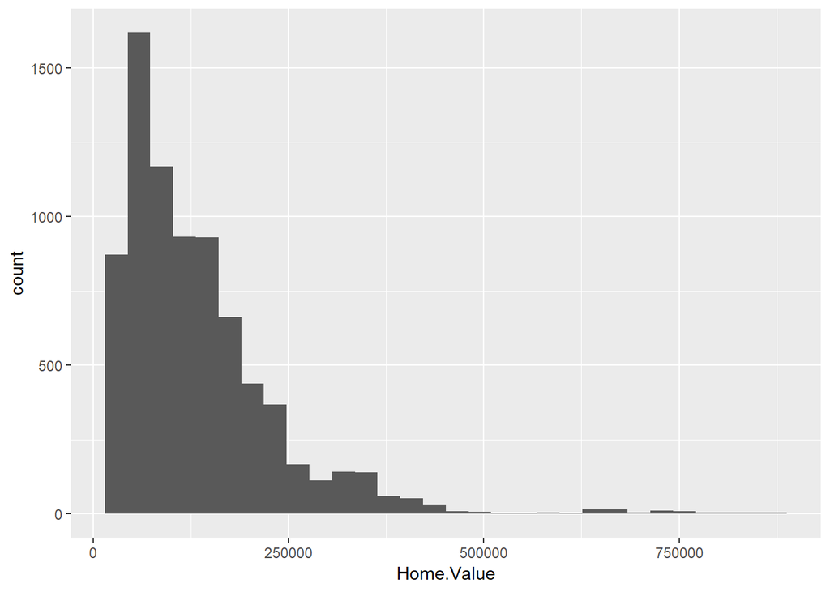

```r
ggplot(housing, aes(x = Home.Value)) + geom_histogram()
```

- Noten que la sintaxis de `ggplot2` toma como primer argumento la base de datos, luego con `aes` el valor del eje, y luego incluye un término que define el tipo de gráfico.
- Veamos esto con una grÃ¡fica de la serie de tiempo del valor de las casas.
- Veamos como serÃ?a en `ggplot2`.

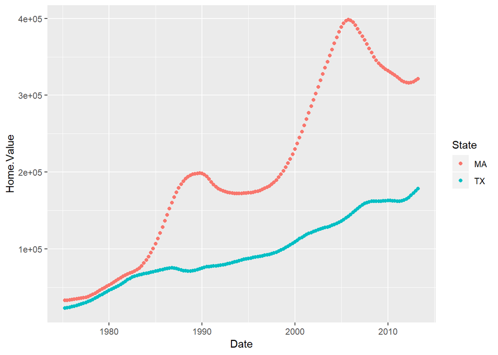

```r
ggplot(subset(housing, State %in% c("MA", "TX")), aes(x=Date, y=Home.Value, color=State)) + geom_point()
```

### Mapeo estÃ©tico

- En `ggplot2` por estÃ©tico entendemos lo que podemos ver.
- Por ejemplo, posiciÃ³n, color, relleno, forma, tipo de lÃ?nea, tamaÃ±o.
- Cada objeto geomÃ©trico acepta solo un subconjunto de opciones estÃ©ticas.
- El mapeo estÃ©tico se establece con la funciÃ³n `aes()`.

### Objetos geomÃ©tricos

- Los objetos geomÃ©tricos son las marcas que ponemos en una grÃ¡fica. Por ejemplo:
  - Puntos (`geom_point`)
  - LÃ?neas (`geom_line`)
  - Boxplots (`geom_boxplot`)
- Una grÃ¡fica debe tener al menos un `geom`. Puede tener mÃ¡s de uno.
- Con el operador `+` se pueden aÃ±adir mÃ¡s `geom`.
- Para un listado de todos los objetos geomÃ©tricos disponibles usar:

```r
help.search("geom_", package="ggplot2")
```

- Veamos algunos ejemplos

### Puntos (Scatterplot)

- Con la funcion `aes` y los objetos geomÃ©tricos podemos hacer grÃ¡ficas en `ggplot2`.
- Como mÃ?nimo necesitamos mapear $x$ y $y$. Luego hay algunas opciones:

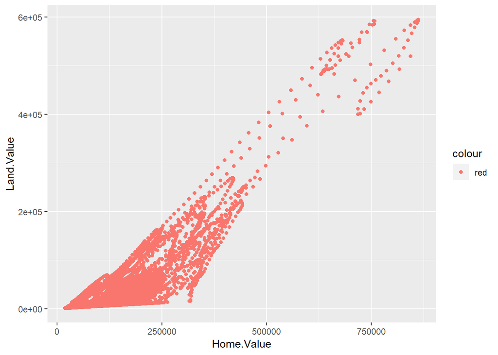

```r
ggplot(housing, aes(y=Land.Value, x=Home.Value, col="red")) + geom_point()
```

- Tenemos demasiadas observaciones como para ver algo claro.
- Acotemos el anÃ¡lisis Ãºnicamente al primer trimestre de 2002

```r
housing2002Q1 <- subset(housing, Date==2002.25)
```

- Y construyamos el scatterplot solo para este periodo:

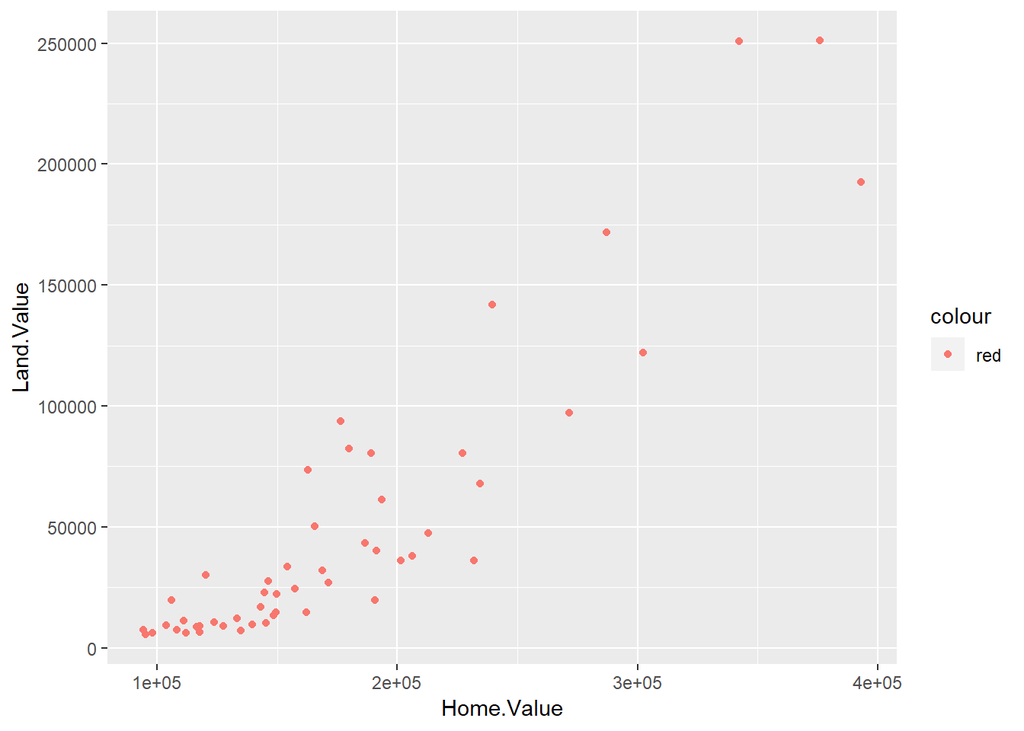

```r
ggplot(housing2002Q1, aes(y=Land.Value, x=Home.Value, col="red")) + geom_point()
```

- Mucho mÃ¡s claro.
- Podemos hacer transformaciones a variables y graficarlas:

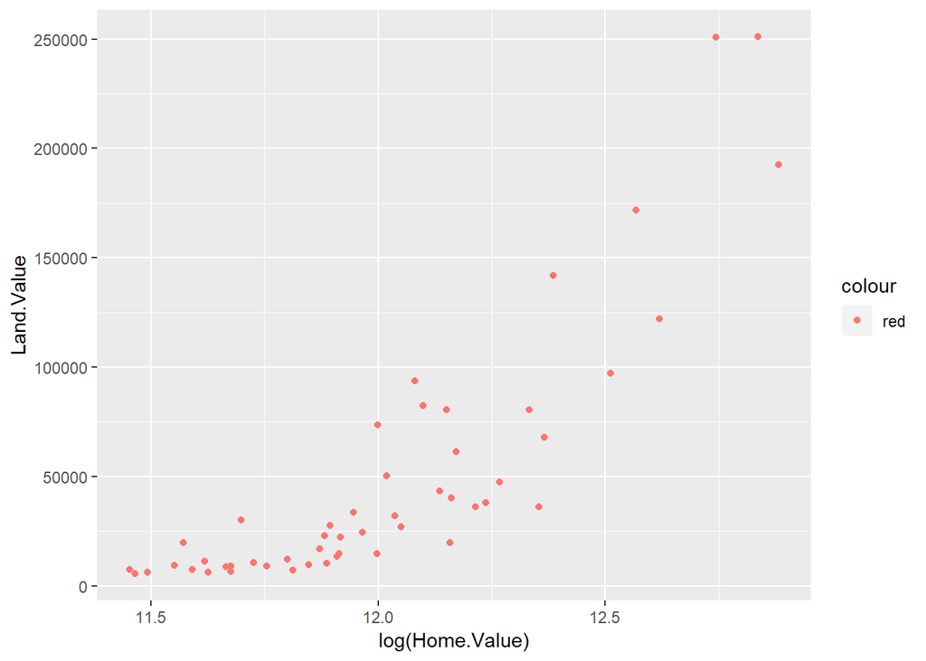

```r
ggplot(housing2002Q1, aes(y=Land.Value, x=log(Home.Value), col="red")) + geom_point()
```

### Lineas (linea de prediccion)

- Podemos tener mÃ¡s de un objeto geomÃ©trico en una misma grÃ¡fica.
- Por ejemplo, podemos graficar la recta de regresiÃ³n a la grÃ¡fica que ya tenemos.
- Primero, corramos la regresiÃ³n de `Land.Value` contra `Home.Value` y pronostiquemos:

```r
housing2002Q1$pred.LV <- predict(lm(Land.Value ~ log(Home.Value), data = housing2002Q1))
```

- Definamos el plano:

```r
p1 <- ggplot(housing2002Q1, aes(x=log(Home.Value), y=Land.Value))
```

- Grafiquemos en dicho plano las observaciones y la recta de regresiÃ³n

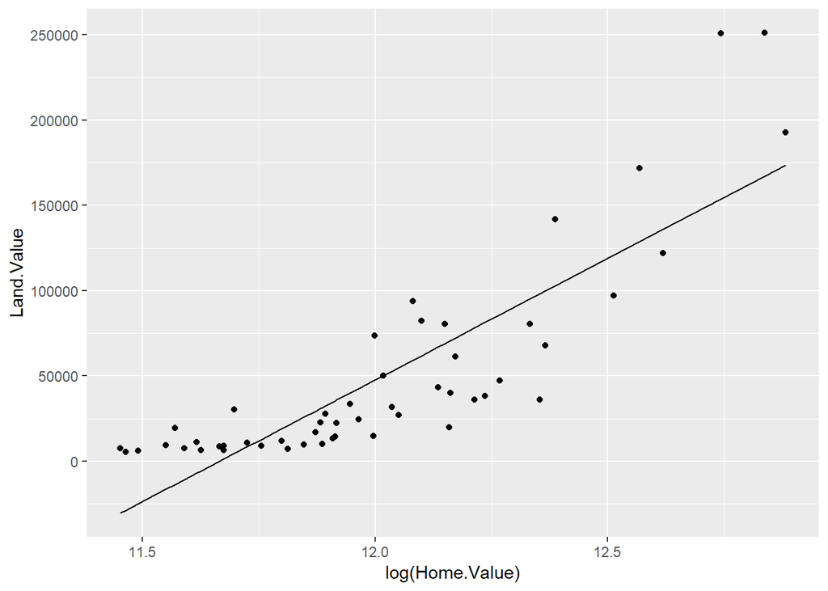

```r
p1 + geom_point()+geom_line(aes(y=pred.LV))
```

- Hay otro tipo de ajustes mÃ¡s sofisticados (no-parametricos):

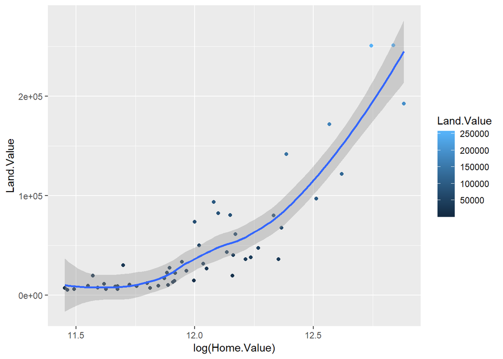

```r
p1 + geom_point(aes(color=Land.Value)) + geom_smooth()
```

### Texto (Label Points)

- Cada `geom` permite algunos mapeos particulares.
- Por ejemplo, `geom_text` acepta `labels`.

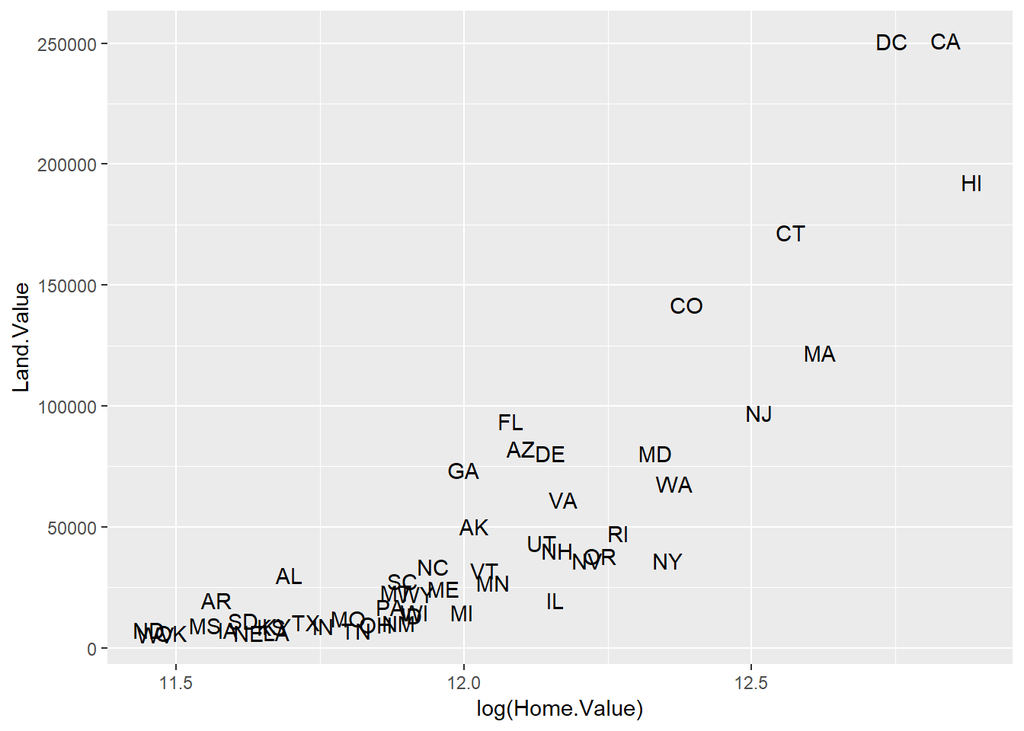

```r
p1+geom_text(aes(label=State))
```

- El tamaÃ±o de los labels no nos ayuda mucho en este caso.

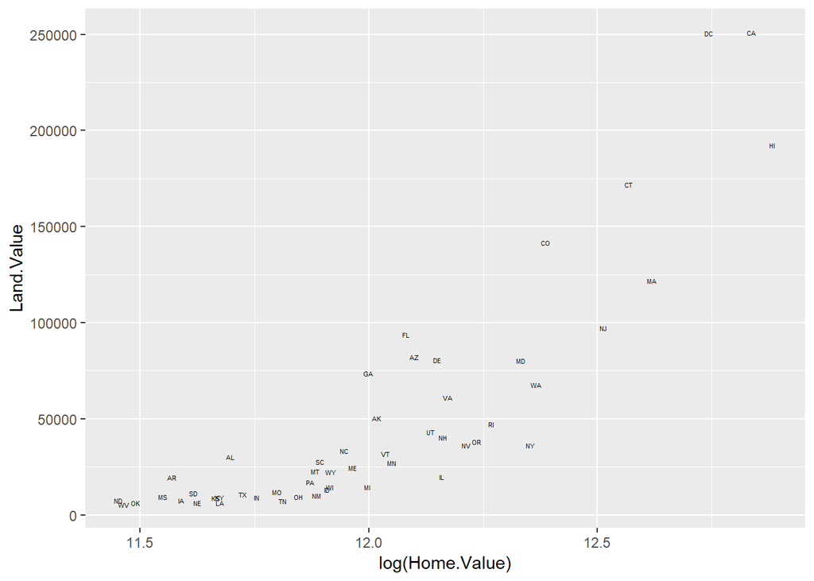

```r
p1+geom_text(aes(label=State), size=1.5)
```

### Barras

- Es fácil hacer gráficas de barras:

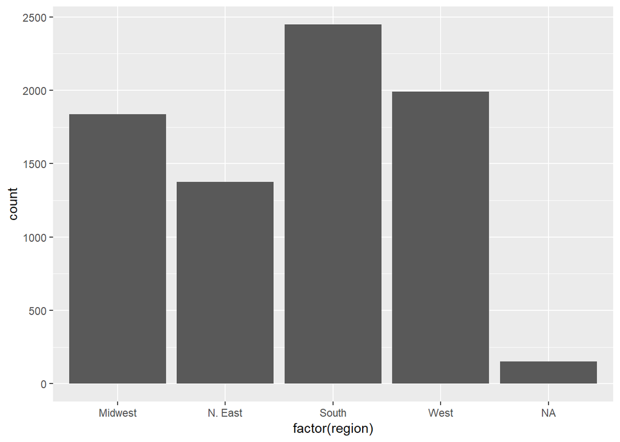

```r
ggplot(housing, aes(factor(region)))+geom_bar()
```

- Le podemos poner algo de color:

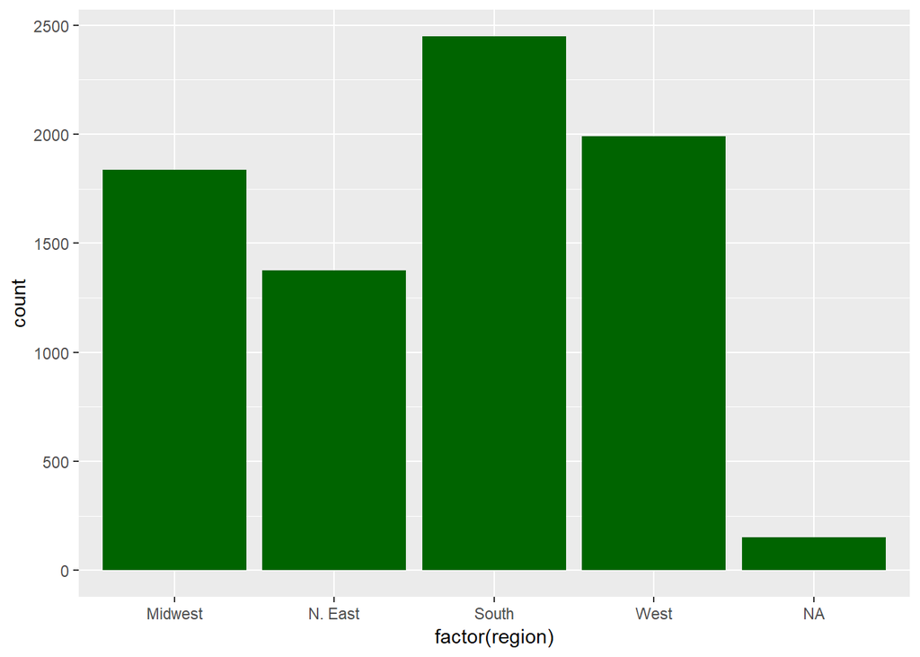

```r
ggplot(housing, aes(factor(region))) + geom_bar(fill="darkgreen")
```

- Hay otra funciÃ³n, `qplot`, que es Ãºtil para este tipo de grÃ¡ficas.
- La sintaxis es distinta:

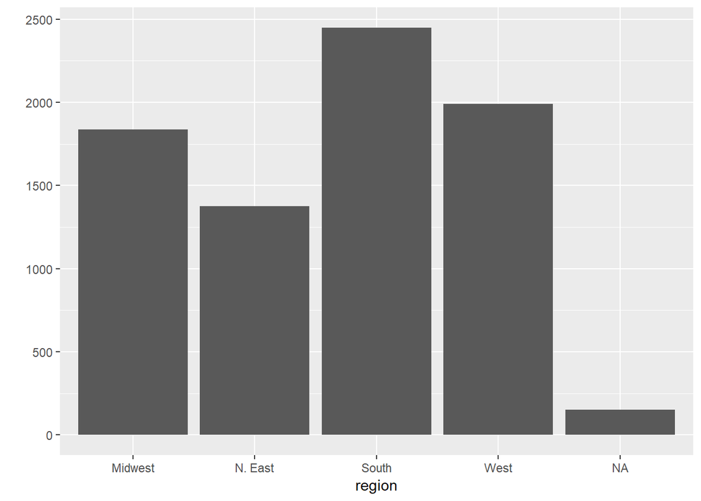

```r
qplot(region, data=housing, geom="bar")
```

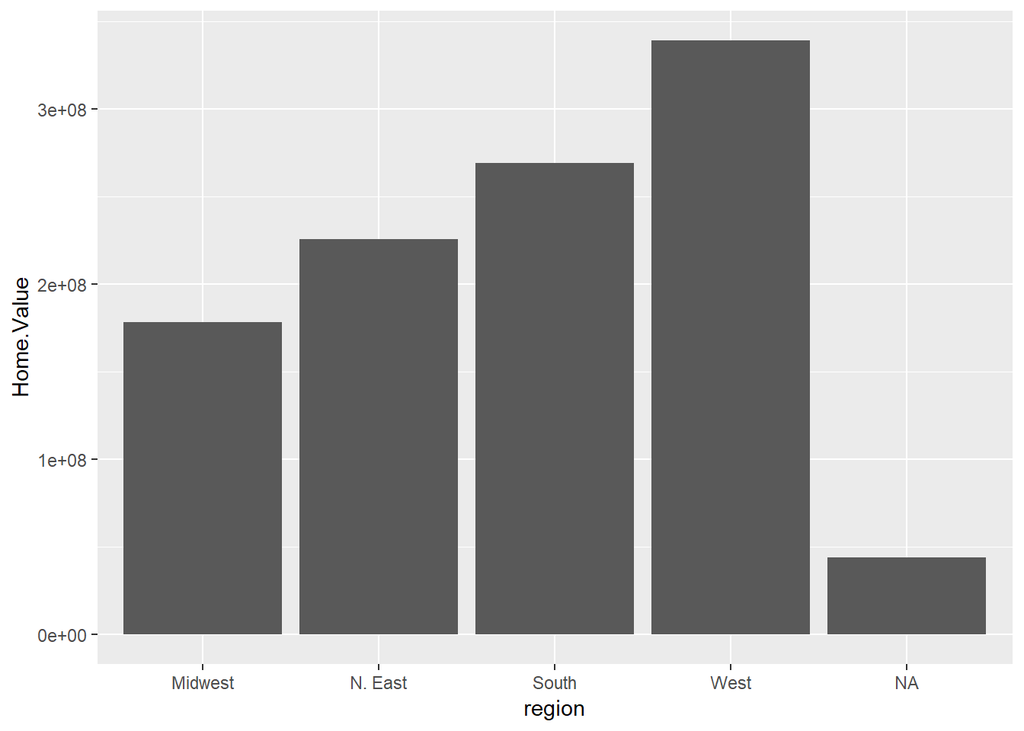

```r
qplot(region, data=housing, geom="bar", weight=Home.Value, ylab="Home.Value")
```

- Y le podemos poner un poco de color:

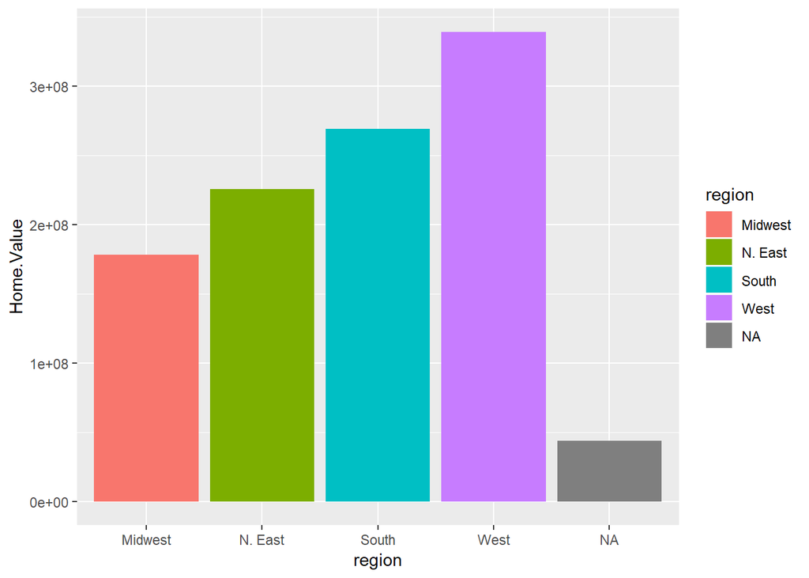

```r
qplot(region, data=housing, geom="bar", weight=Home.Value, ylab="Home.Value", fill=region)
```